# Stats 369 Assignment 4

Hasnain Cheena

29/10/2020

# YRBS

## Load in the data

```r
set.seed(369)
load("yrbs.rda")

#remove observations where labels are NA
missing_labels = is.na(r)
features = data.matrix(x[!missing_labels, ])
labels = r[!missing_labels]
```

## Question 1

Build a classifier to predict labels r from x with xgboost, and show the confusion matrix.

```r
#perform CV to assess the number of boosting rounds necessary
xgb.cv(data = features, label=labels, num_class = 8, max_depth = 6, nrounds = 20, eta=0.5, nfold= 5, objective="multi:softmax")
```

```r
#fit XGBoost model
nrounds = 7
nclass = 8
bst = xgboost(data = features, label = labels, num_class = nclass, max_depth = 6, eta = 0.5, nrounds = nrounds, objective = "multi:softmax")
# Create confusion matrix
table(actual=labels, predictions = predict(bst, newdata = features))
```

```
##       predictions
## actual    0    1    2    3    4    5    6    7
##      0   34    2   11    0   82   11   23    0
##      1    0  221   29    0  227   95   54    1
##      2    0   10  958    0  355  159  183    2
##      3    0    2   15   25   31   13   14    0
##      4    0   10  147    0 6261  218  212    1
##      5    0    6  135    0  708 1104  412    0
##      6    0   18  153    0 1006  406 1173    0
##      7    0   12   88    0  417   52  102   68
```

## Question 2

Describe and visualize which variables are most important in the prediction.

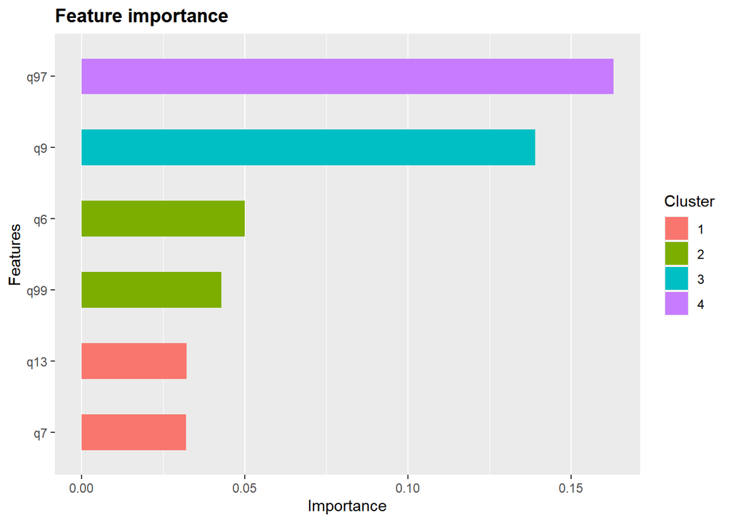

```r
key_features = xgb.importance(model = bst)
xgb.ggplot.importance(key_features, top_n = 6)
```

## Question 3

Describe and display the relationships between the most important variables and the label categories – which category/categories is each of the most important variables useful for predicting? Can you produce a summary of the most distinctive predictors for each label category?

```r
#recode some of the variables to make them easier to understand

# Make x a data frame so we can use it to plot, and get a list of the top 6 questions
x.df = as.data.frame(features)
top_q = paste0("q", c(97, 9, 6, 7, 99, 13))
top_q.df = x.df %>% select(top_q)
# Make all entries which have value NA, have a value of "Missing"
top_q.df[is.na(top_q.df)] = "Missing"

#recode question 97
top_q.df$q99 = as.factor(top_q.df$q99)
levels(top_q.df[,1]) = c("0", "1", "2", "3", "4", "5 or more", "Missing")

#recode question 9
top_q.df$q9 = as.factor(top_q.df$q9)
levels(top_q.df[,2]) = c("Never", "Rarely", "Sometimes", "Most of the time", "Always", "Missing")

#recode question 6 as they are just heights
top_q.df$q6 = as.numeric(top_q.df$q6)


#recode question 7 as they are just weights
top_q.df$q7 = as.numeric(top_q.df$q7)


# Recode question 99
top_q.df$q99 = as.factor(top_q.df$q99)
levels(top_q.df[,5]) = c("Very well", "Well", "Not well", "Not at all", "Missing")

# Recode question 13
top_q.df$q13 = as.factor(top_q.df$q13)
levels(top_q.df[,6]) = c("0 days", "1 day", "2 or 3 days", "4 or 5 days", "6 or more days", "Missing")


# Append the race value to the end of the matrix and recode the numbers to the name of the race, and make it a factor type
top_q.df = cbind(top_q.df, "Race" = labels)

top_q.df$Race = as.factor(top_q.df$Race)
levels(top_q.df$Race) = c("American Indian/ Alaskan Native", "Asian", "Black/ African American", "Native Hawaiian or other Pacific Islander", "White", "Hispanic/ Latino", "Multiple race and Hispanic/ Latino", "Multiple-race but not Hispanic/ Latino")
```

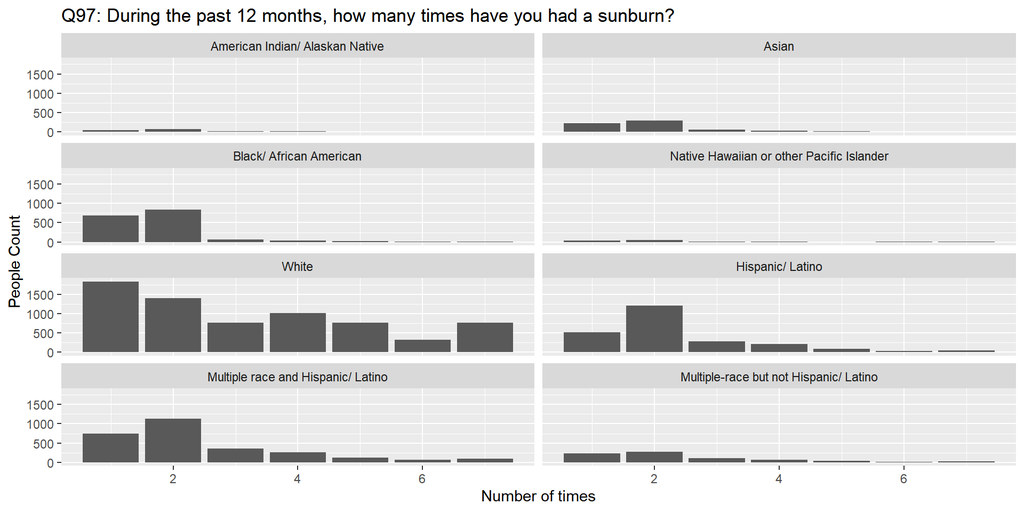

```r
#Q97
top_q.df %>%
  ggplot(aes(x=q97)) +
  geom_bar() + facet_wrap(~Race, nrow=4) +
  xlab("Number of times") + ylab("People Count") +
  ggtitle("Q97: During the past 12 months, how many times have you had a sunburn?")
```

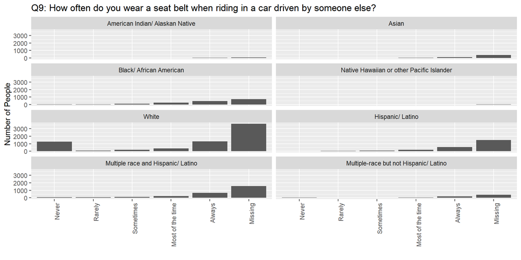

```r
#Q9
top_q.df %>%
  ggplot(aes(x=q9)) +
  geom_bar() + facet_wrap(~Race, nrow=4) +
  xlab("") + ylab("Number of People") +
  ggtitle("Q9: How often do you wear a seat belt when riding in a car driven by someone else?") +
  theme(axis.text.x=element_text(angle=90, hjust=1))
```

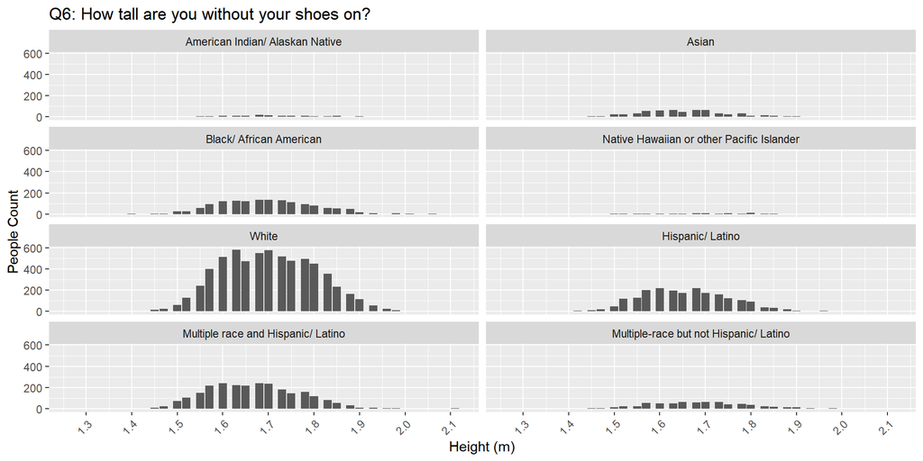

```r
#Q6
top_q.df  %>%
  ggplot(aes(x=q6)) +
  geom_bar() + facet_wrap(~Race, nrow=4) +
  xlab("Height (m)") + ylab("People Count") +
  ggtitle("Q6: How tall are you without your shoes on?") +
  theme(axis.text.x=element_text(angle=45, hjust=1)) + scale_x_continuous(breaks = seq(0, 2.5, 0.1))
```

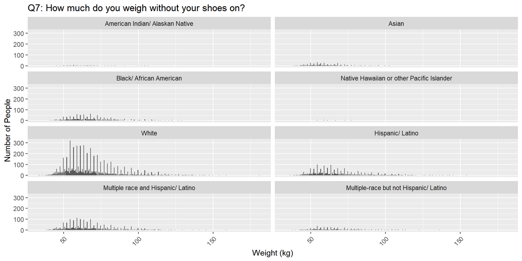

```r
#Q7
top_q.df  %>%
  ggplot(aes(x=q7)) +
  geom_bar() + facet_wrap(~Race, nrow=4) +
  xlab("Weight (kg)") +
  ylab("Number of People") +
  ggtitle("Q7: How much do you weigh without your shoes on?") +
  theme(axis.text.x=element_text(angle=45, hjust=1))
```

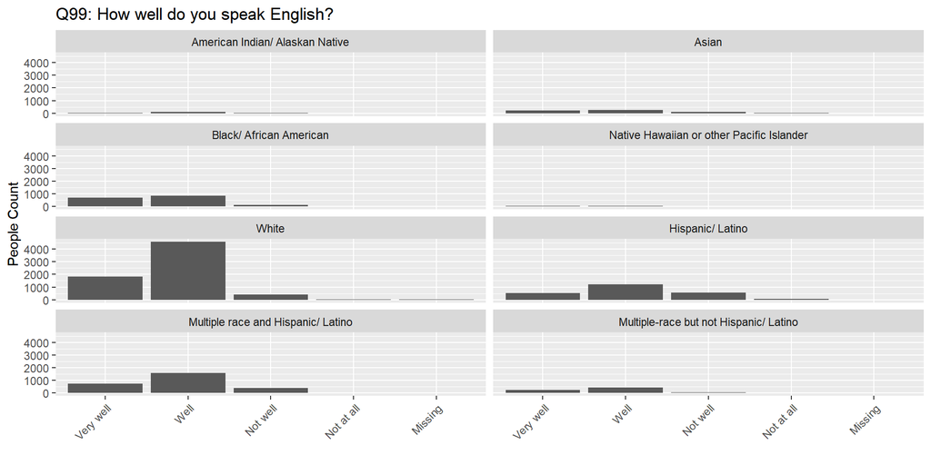

```r
#Q99
top_q.df %>%
  ggplot(aes(x=q99)) +
  geom_bar() + facet_wrap(~Race, nrow=4) +
  xlab("") + ylab("People Count") +
  ggtitle("Q99: How well do you speak English?") + theme(axis.text.x=element_text(angle=45, hjust=1))
```

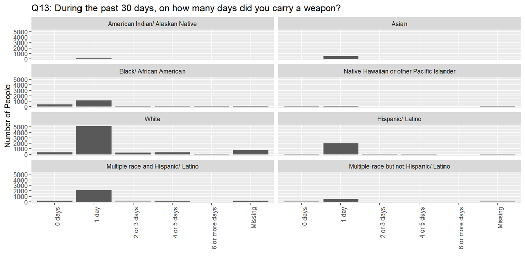

```r
#Q13
top_q.df %>%
  ggplot(aes(x=q13)) +
  geom_bar() + facet_wrap(~Race, nrow=4) +
  xlab("") + ylab("Number of People") +
  ggtitle("Q13: During the past 30 days, on how many days did you carry a weapon?") +
  theme(axis.text.x=element_text(angle=90, hjust=1))
```

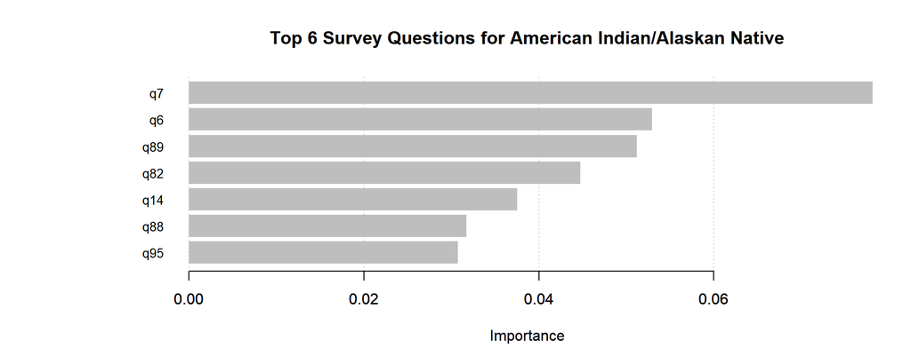

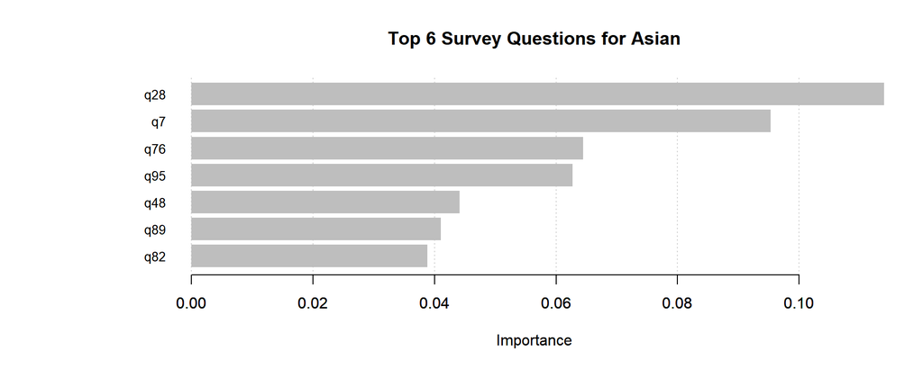

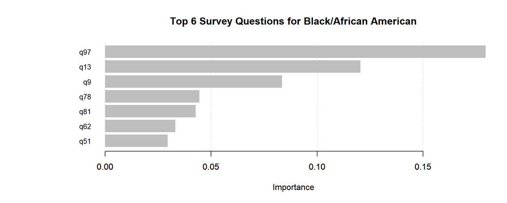

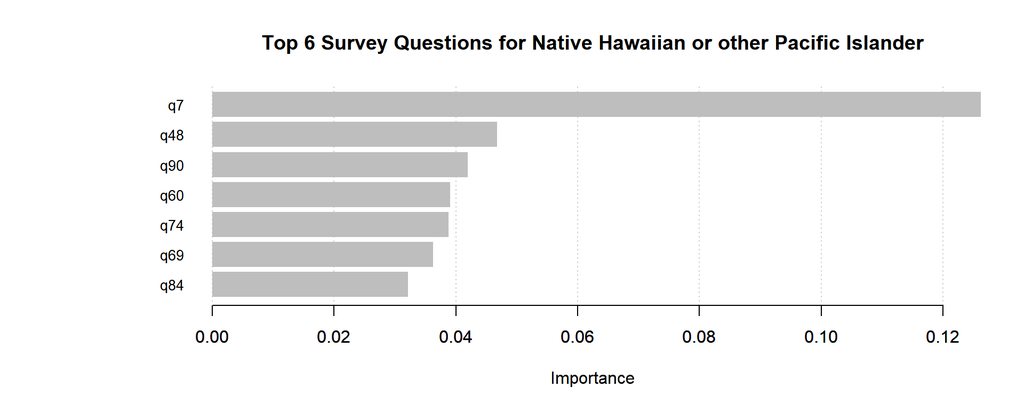

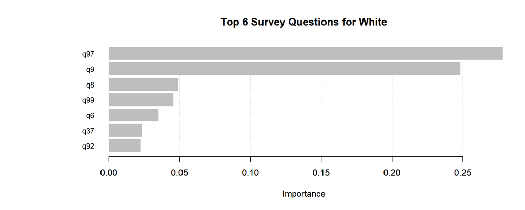

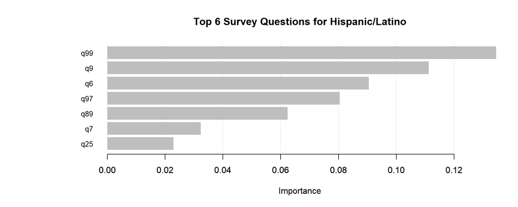

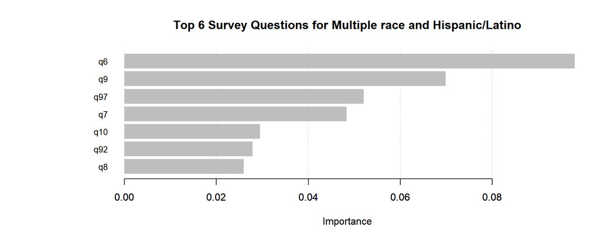

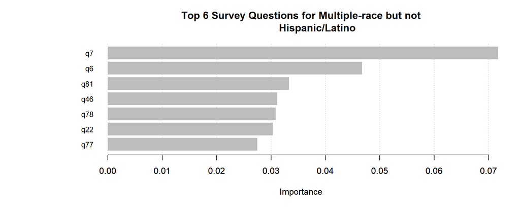

```r
#summary of predictors for each label category
races = c("American Indian/Alaskan Native", "Asian", "Black/African American",
           "Native Hawaiian or other Pacific Islander", "White", "Hispanic/Latino", "Multiple race and Hispanic/Latino", "Multiple-race but not
           Hispanic/Latino")
for (idx in 0:7) {
  importance_per_race = xgb.importance(model = bst, trees = seq(idx, by=nclass, length.out = nrounds))
  xgb.plot.importance(importance_per_race, top_n = nrounds , main=paste0("Top 6 Survey Questions for ", races[idx+1]), xlab="Importance")
}
```

The above plots show a summary of the most distinctive predictors for each ethnic category.

## Question 4

Comment on whether (or not) task 3 would be ethically problematic if intended to be published, and for what reasons

Task 3 is not ethically problematic if published.

- This is because it is a visualization of the data meaning we cannot identify which students or which schools have been surveyed.
- The data is sourced from a government agency, therefore it does have some credibility and reliability, however there is still a chance of inaccurate answers. This is because both from students may answer falsely and human error caused by data entry.
- Furthermore, the responsibility of the data being used properly is fulfilled as the visualizations above do not have any hidden agenda. They are simple, easy to understand visuals that can be helpful in predicting which high school students need help, and thus can get help earlier.
- However, we do have missing / NA values in the data, meaning that the answer to some questions have not been included in the model, which affects the accuracy of the model. This means the visualization and results should be considered with a grain of salt.

In conclusion, the purpose of the visualization was to give more clarity to the data, it is honest and is fit for the purpose to educate and assist decision makers help youth at health risk.

(Points sourced and applied from data ethics lectures)